# Statistical Graphics and Communication

Stefany Coxe

September 12, 2019

# Visual Perception

## Visual objects

Information in graphics is encoded in visual attributes

- Position
- Size
- Color
- Angle
- Area
- Etc.

Comparisons, estimates of magnitude, and patterns are determined by the visual features

## Encoding and decoding information

To use a graphic

- Data is encoded into the graphic
- A person views the graphic
- The person decodes the visual elements to get information

We should try to make this last step as easy as possible, given the limitations of a human

## Perception

Basic research on perception

- Generally from cognitive (and related) areas

Applied research on perception

- Often comes out of “human factors” areas

## Bottom-up versus top-down perception

Bottom-up processing

- Start with basic perceptual features (e.g., edges, color)
- Use those to work up to shapes and patterns
- Uninfluenced by expectations
- Pre-attentive

Top-down processing

- Driven by expectations, experiences, knowledge
- Filters what we see through that

## Bottom-up example

How many 8s?

11768583633938959279

## Bottom-up example

How many 8s?

11768583633938959279

How many 8s?

## Bottom-up example

In the first set, you have to read and process the numbers

When the numbers are a different color, you notice the **color** before you can even tell that they’re 8s

Color is processed bottom-up (pre-attentionally)

- This is the same effect you see with the Stroop task (but in the opposite direction, where you read the word easier than you name the color) https://en.wikipedia.org/wiki/Stroop_effect

## Top-down example

What is this an image of?

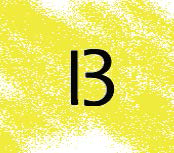

## Top-down example

It depends on the *context*

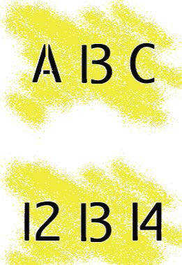

Top-down processing helps you decide whether it’s a letter or numbers

## Gestalt

Type of top-down processing

We tend to see things that are

- near one another
- similar to one another
- continuations of one another or connected to one another
- in a common region
- moving together

as being a distinct unit (even if they’re not)

## Gestalt

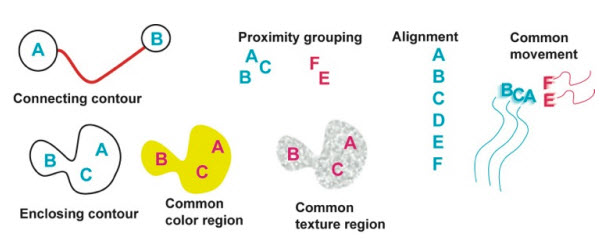

From http://blog.yhwu.me/notes/visualizations/cs171.html

## Figure-ground

The figure is the thing you’re focusing on

The ground is the rest – think, “background”

- Many common illusions based on figure-ground ambiguity
- e.g. Rubin’s vase: https://en.wikipedia.org/wiki/Rubin_vase

Can lead to ambiguous or **misleading** graphics

## Figure-ground in graphics

[figure not shown]

Original from: https://www.businessinsider.com/gun-deaths-in-florida-increased-with-stand-your-ground-2014-2

## Figure-ground in graphics

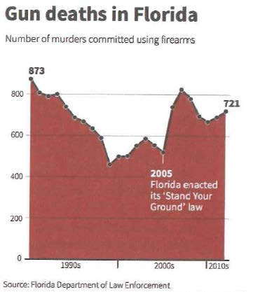

Modification by: https://twitter.com/PFedewa

## Visual illusions

- Muller Lyre illusion:

https://en.wikipedia.org/wiki/M%C3%BCller-Lyer_illusion

- Ebbinghaus or Tichener illusion:

https://en.wikipedia.org/wiki/Ebbinghaus_illusion

- Ponzo illusion:

https://en.wikipedia.org/wiki/Ponzo_illusion

All of these illusions exist because of top-down processing / heuristics / context

## What are we good at?

We’ve seen a bunch of examples of what we’re bad at and how perception can go wrong

- How can it go right?
- What are we good at?

It turns out, quite a few things

## Judging whether a line is straight or not

Q-Q plot: quantile-quantile plot

https://en.wikipedia.org/wiki/Q%E2%80%93Q_plot

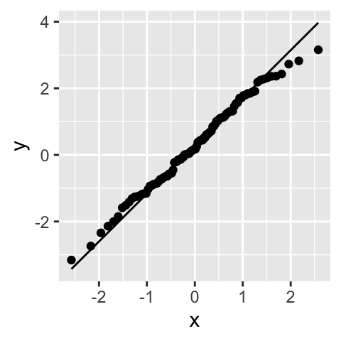

## Judging magnitude (sometimes)

Cleveland & McGill (1984) and Heer & Bostock (2010) had people judge magnitude based on different visual representations

From highest accuracy to lowest:

- Position
- Angle
- Circular area
- Rectangular area

Position = good

Area = bad

## Effectiveness of different representations for comparisons

Munzner (2015) book: Visualization Analysis & Design

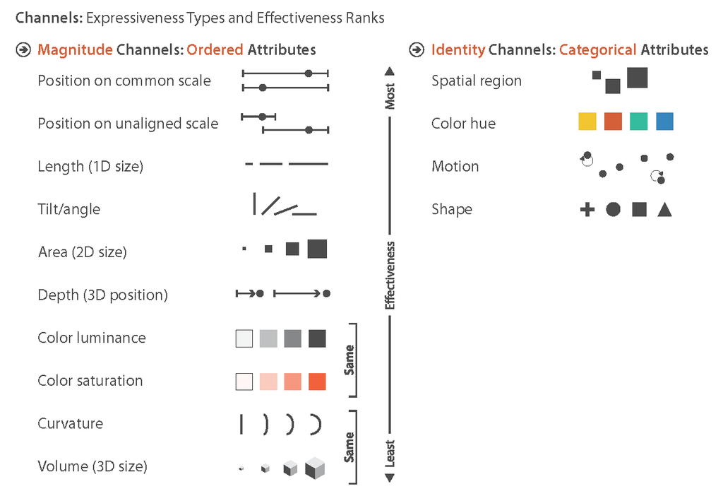

## Conclusions

We are good at comparing position and length

- We are bad at comparing areas, volumes, curvature

Use bar plot or dot plot (length and position, respectively)

- Instead of circles or squares (areas, volumes)

Attributes that are processed bottom-up (pre-attentionally) are better

- e.g., color for categorical variables
- Color on a continuum is trickier
- We’ll talk about color more in a second

Be aware of potential illusions

## Additional links

[Michael Friendly’s Psychology of Data Visualization course](http://euclid.psych.yorku.ca/www/psy6135/)

[Great examples of pre-attentive processing](https://www.csc2.ncsu.edu/faculty/healey/PP/)

# Color

## Use of color

We use color in plots to

- Highlight
- Identify
- Group

the elements in a graphic

## Physiology of color perception

In the retina, there are 3 types of *cones*

Each cone is sensitive to a specific range of light wavelengths

- red, green, or blue

There are also *rods* that help distinguish black and white

The color we perceive is determined by how much (relatively) each of the cones is activated by visible light

- All red cones activated + no blue or green = we see red
- Some blue, some green = we seen blue-green

There are many theories of exactly how we perceive color, but for our purposes, those details don’t really matter

- Focus on how we *define* color for the purposes of graphics

## Hue, saturation, lightness

Hue

- What we would colloquially call the “color”
- Red, blue, yellow, etc.

Saturation

- Intensity of the color, from very little color (close to grey) to pure color

Lightness (or brightness)

- Relative lightness or darkness
- Black = no lightness
- White = full lightness

Colors can vary along any or all of these dimensions

## Categorical, sequential, diverging color schemes

**Categorical**: different **hues**, similar **saturation**

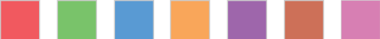

**Sequential**: similar **hues** of varying **saturation**

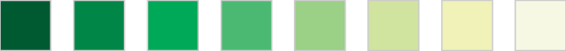

**Diverging**: two sequential schemes

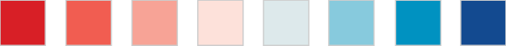

From: http://www.perceptualedge.com/articles/visual_business_intelligence/rules_for_using_color.pdf

## Color vs black and white

What will your plot look like if it’s converted to black and white?

- Incorrect interpretations due to common illusions
- e.g., https://en.wikipedia.org/wiki/File:Gradient-optical-illusion.svg
- **Saturation** is very important

Categorical scheme has the same **saturation** for all colors

- You can’t see any differences between colors

Sequential scheme varies **saturation** / intensity

- You can still see all the differences

Diverging scheme varies **saturation**, but two ends are similar

- You can still see which are in the middle and which are at the ends, but probably can’t tell the two ends from one another

## Alpha

Adjusting the transparency / opacity (alpha) of colors can enhance their use

- The points for different groups are different colors, but they may be obscured due to overplotting
- Color plus reduced alpha lets you use color to distinguish groups while still being able to see all the points

Adjusting alpha may look similar to adjusting saturation

- But stacked points with reduced alpha create high saturation areas

## Color creation schemes

RGB: red, green, blue

- Mixture of all = white
- Computer monitors, film
- FIU blue = (8, 30, 63)

CMYK: cyan, magenta, yellow (and black)

- Mixture of all = black
- Physical printing
- FIU blue = (100, 87, 42, 52)

Hexadecimal

- Web-based purposes (i.e., HTML)
- FIU blue = #081E3F

## Colorblindness

Genetic loss of one (or more) cone type

Most common is red-green color blindess

- Red and green are indistinguishable

Choose a color scheme that doesn’t depend on people needing to distinguish between these colors

- Remember to consider other properties of the color besides the color (hue), like saturation

Test your plot to see how it looks to a person who is color blind

- https://www.color-blindness.com/coblis-color-blindness-simulator/

## Colors in ggplot2

We will have most of a lecture on the details of using color in ggplot

- Changing the overall color theme for a plot
- Changing the color of individual parts of a plot

Today, the focus is on color as a perceptual concept

# Other design decisions

## Wind frequency and direction

Radial bar chart is a good choice to see the prevailing wind direction

- But not to be able to **compare** wind direction frequencies

What is the purpose of the graphic?

https://medium.com/nightingale/breaking-the-rules-bd212fecd045

## Tips for making good graphics

In terms of small design decisions (based on cognition and perception)

- High contrast color choices
- Minimize distractions
- Story of the graphic should jump out at you – squint at it (or take off your glasses)

https://www.dataquest.io/blog/design-tips-for-data-viz/

## Some advice based on Tufte and Robbins

Data-to-ink ratio

- Remove extra or decorative lines

Reduce the mental processing needed

- Don’t make your viewer do more mental work than they need to

http://stat545.com/block015_graph-dos-donts.html

## Does the Y axis **need** to start at 0?

- Yes, for some types of charts

https://flowingdata.com/2015/08/31/bar-chart-baselines-start-at-zero/

- Maybe

https://byjustinfox.com/2014/12/14/the-rise-of-the-y-axis-zero-fundamentalists/

(But some of the people quoted here say **YES**)

- No, shut up about the y-axis.

https://www.youtube.com/watch?v=14VYnFhBKcY